# Erin Liu HW6

HW6

Erin Liu  
2022-01-20

### Research questions and dataset

Nowadays when people book hotels, there are many factors that could affect the daily price of the hotel rooms (known as ADR: The number represents the average rental income per paid occupied room in a given time period[1]). In this project, I will be using the advanced dataset “hotel_bookings.csv” from the “Sample Datasets” section on Google Classroom and I will be studying the relationship between ADR(average daily rate for hotel booking) and several other common factors(such as the amount of time that people booked the hotel ahead of(lead_time), customer types and room types) that play a role in people’s decision in terms of booking hotel and try to find a conclusion of which situation will give the cheapest daily rate.

```r
HW3_data<- read.csv('/Users/erinliu/Downloads/hotel_bookings.csv',TRUE,',')
```

### Data cleaning and wrangling

Since I will be studying the influence of different factors on ADR, I will first need to clean the dataset to have all positive ADR. In addition, I will shorter the range of lead_time to be between 0 and 300 and ADR below 300 for further analysis.

```r
 resort_hotel_data <- filter(HW3_data, adr > 0 & hotel=="Resort Hotel" & lead_time>0 & lead_time<300 & adr<300)
 city_hotel_data <- filter(HW3_data, adr > 0 & hotel=="City Hotel" & lead_time>0 & lead_time<300 & adr<300)
```

### Descriptive Statistics

mean, median, and standard deviation for numerical variables, and frequencies for categorical variables.

```r
summarize(resort_hotel_data, mean.resort_lead_time = mean(`lead_time`),
          mean.resort_ADR = mean(`adr`),
          mean.resort_days_weekend_stay = mean(`stays_in_weekend_nights`),
          mean.resort_days_weekday_stay = mean(`stays_in_week_nights`))
```

```
  mean.resort_lead_time mean.resort_ADR mean.resort_days_weekend_stay
1              89.52453        97.55005                       1.25622
  mean.resort_days_weekday_stay
1                      3.271196
```

```r
summarize(resort_hotel_data, median.resort_lead_time = median(`lead_time`),
          median.resort_ADR = median(`adr`),
          median.resort_days_weekend_stay = median(`stays_in_weekend_nights`),
          median.resort_days_weekday_stay = median(`stays_in_week_nights`))
```

```
  median.resort_lead_time median.resort_ADR
1                      65            79.135
  median.resort_days_weekend_stay median.resort_days_weekday_stay
1                               1                               3
```

```r
summarize(resort_hotel_data, sd.resort_lead_time = sd(`lead_time`),
          sd.resort_ADR = sd(`adr`),
          sd.resort_days_weekend_stay = sd(`stays_in_weekend_nights`),
          sd.resort_days_weekday_stay = sd(`stays_in_week_nights`))
```

```
  sd.resort_lead_time sd.resort_ADR sd.resort_days_weekend_stay
1            81.72569      58.94009                    1.143435
  sd.resort_days_weekday_stay
1                    2.446155
```

```r
summarize(city_hotel_data, mean.city_lead_time = mean(`lead_time`),
          mean.city_ADR = mean(`adr`),
          mean.city_days_weekend_stay = mean(`stays_in_weekend_nights`),
          mean.city_days_weekday_stay = mean(`stays_in_week_nights`))
```

```
  mean.city_lead_time mean.city_ADR mean.city_days_weekend_stay
1            91.16719      108.6206                   0.8371763
  mean.city_days_weekday_stay
1                    2.251454
```

```r
summarize(city_hotel_data, median.city_lead_time = median(`lead_time`),
          median.city_ADR = median(`adr`),
          median.city_days_weekend_stay = median(`stays_in_weekend_nights`),
          median.city_days_weekday_stay = median(`stays_in_week_nights`))
```

```
  median.city_lead_time median.city_ADR median.city_days_weekend_stay
1                    69             101                             1
  median.city_days_weekday_stay
1                             2
```

```r
summarize(city_hotel_data,
          sd.city_lead_time = sd(`lead_time`),
          sd.city_ADR = sd(`adr`),
          sd.city_days_weekend_stay = sd(`stays_in_weekend_nights`),
          sd.city_days_weekday_stay = sd(`stays_in_week_nights`))
```

```
  sd.city_lead_time sd.city_ADR sd.city_days_weekend_stay
1          78.32797    36.94334                 0.8889769
  sd.city_days_weekday_stay
1                  1.465679
```

### Visualizations between ADR and lead_time

This is the visualization between the city_lead_time_category and the count in each category. It shows the distribution of lead_time data in different ranges. We can tell from this graph that most of the lead_time happen in the range of 0-60 and the number of count decreases as lead_time goes larger.

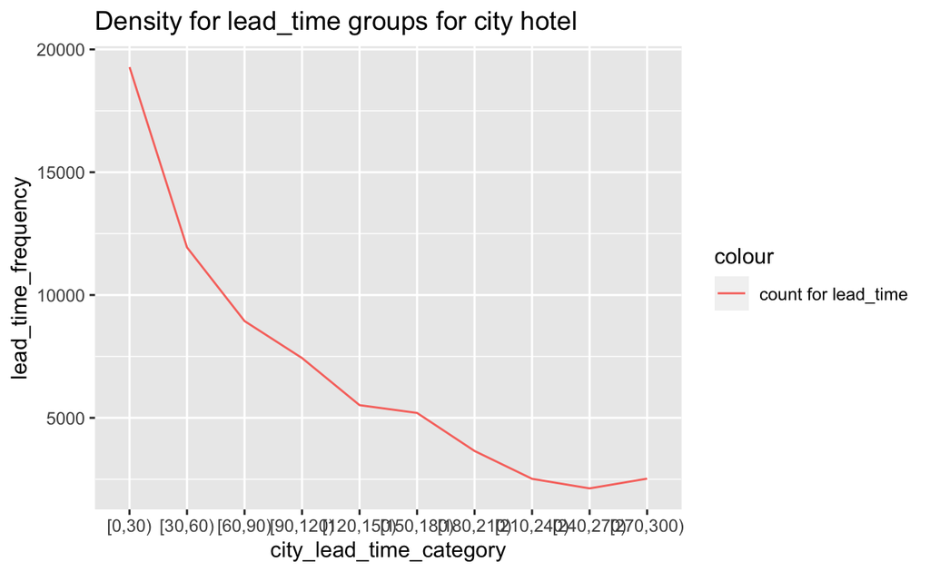

```r
city_hotel_data %>%
  group_by(city_lead_time_category=cut(lead_time, breaks= seq(0, 300, by = 30), right=F) ) %>%
  summarise(lead_time_frequency= n()) %>%
  arrange(as.numeric(city_lead_time_category)) %>%
  ggplot(aes(city_lead_time_category, group = 1)) +
  geom_line(aes(y = lead_time_frequency, colour = "count for lead_time")) +
  labs(title = "Density for lead_time groups for city hotel")
```

This is the visualization about the relationship between ADR and lead_time for city hotel. We can see that although it shows quite a large density around the range of 0-60 (as align with the previous graph), the ADR scatters around the range of 60-200 while the lead_time falls into the range of 0-60, and we can see that the count of higher price of ADR (larger than 150) reduces significantly once the lead_time falls beyond 100 days. This shows that generally price will go down a bit as the lead_time is longer, but not by a significant amount.

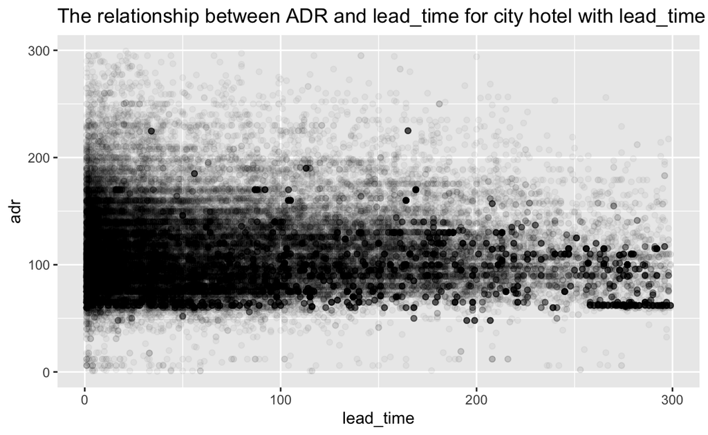

```r
ggplot(city_hotel_data, aes(lead_time, adr)) + geom_point(alpha=0.04) +
labs(title = "The relationship between ADR and lead_time for city hotel with lead_time in category")
```

This is the visualization between the resort_lead_time_category and the count in each category. It shows the distribution of lead_time data in different ranges. We can tell from this graph that most of the lead_time happen in the range of 0-30 and the number of count decreases as lead_time goes larger. As compare to the city hotel, the data of resort hotel shows a shorter range of lead_time as to be the popular option.

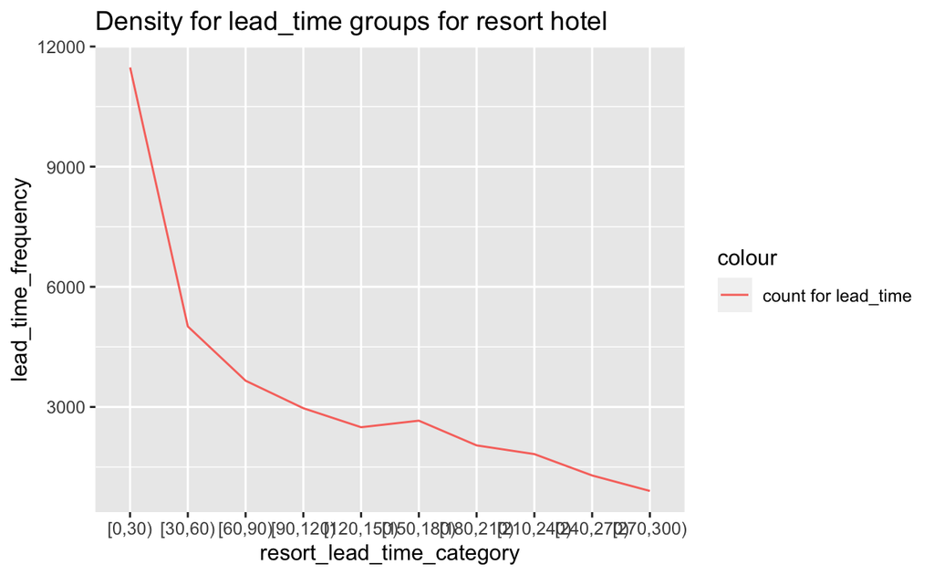

```r
resort_hotel_data %>%
  group_by(resort_lead_time_category=cut(lead_time, breaks= seq(0, 300, by = 30), right=F) ) %>%
  summarise(lead_time_frequency= n()) %>%
 arrange(as.numeric(resort_lead_time_category)) %>%
  ggplot(aes(resort_lead_time_category, group = 1)) +
 geom_line(aes(y = lead_time_frequency, colour = "count for lead_time")) +
  labs(title = "Density for lead_time groups for resort hotel")
```

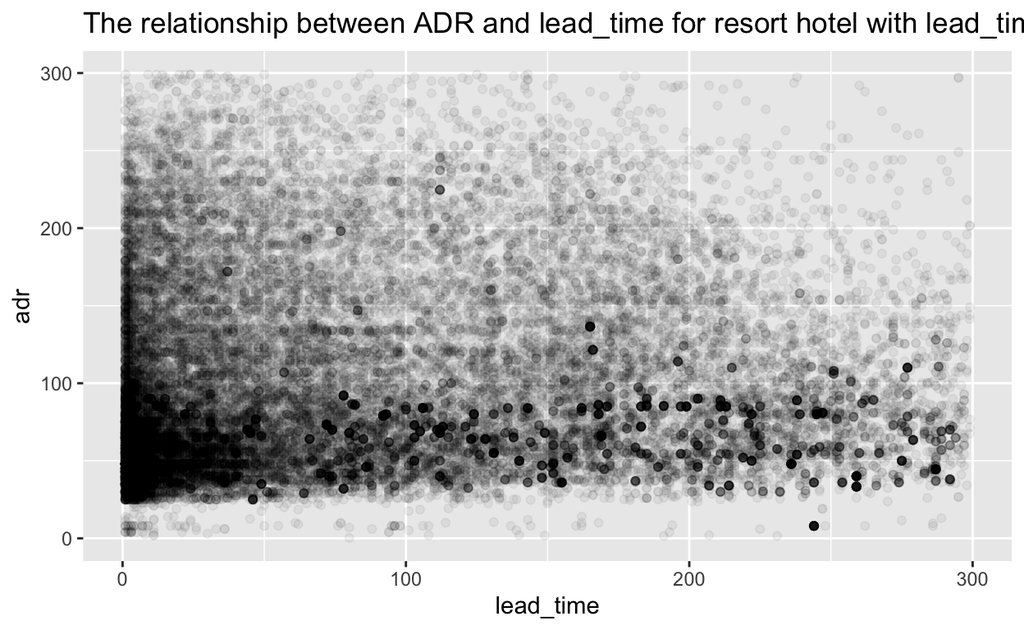

```r
ggplot(resort_hotel_data, aes(lead_time, adr)) + geom_point(alpha=0.05) +
labs(title = "The relationship between ADR and lead_time for resort hotel with lead_time in category")
```

This is the visualization of ADR’s distribution for resort hotel, and it helps us to understand the data more besides the conclusion from mean/median and we can see the peak of frequency happens in around 50.

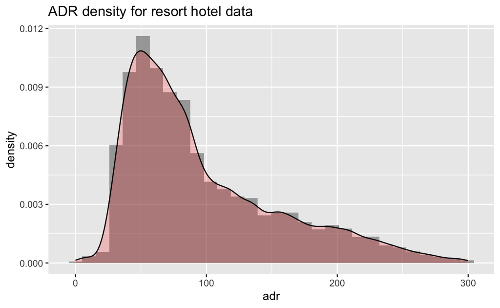

```r
ggplot(resort_hotel_data, aes(adr)) +
  geom_histogram(aes(y = ..density..), alpha = 0.5) +
  labs(title = "ADR density for resort hotel data") +
  geom_density(alpha = 0.2, fill="red")
```

This is the visualization of ADR’s distribution for city hotel, and it helps us to understand the data more besides the conclusion from mean/median and we can see the peak of frequency happens in around 100.

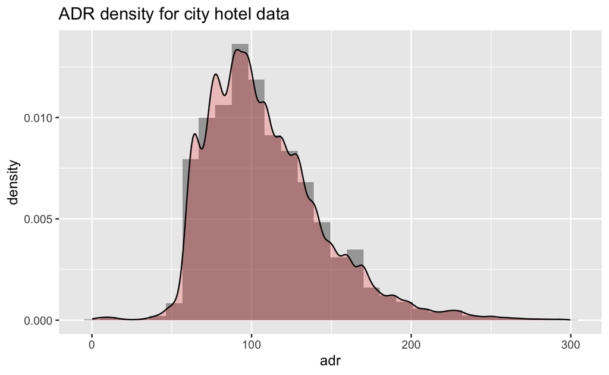

```r
ggplot(city_hotel_data, aes(adr)) +
  geom_histogram(aes(y = ..density..), alpha = 0.5) +
  labs(title = "ADR density for city hotel data") +
  geom_density(alpha = 0.2, fill="red")
```

### Visualizations between ADR and some other factors

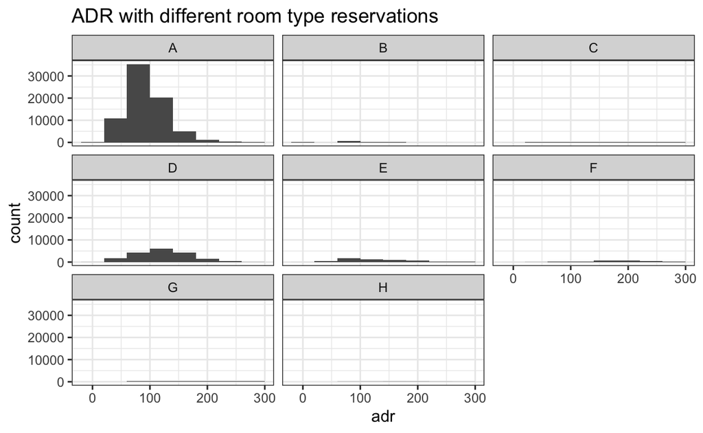

```r
all_data <- filter(HW3_data, adr > 0 & lead_time>0 & lead_time<300 & adr <300 )
ggplot(all_data, aes(adr)) +
  geom_histogram(binwidth = 40) +
  labs(title = "ADR with different room type reservations") +
  theme_bw() +
  facet_wrap(vars(reserved_room_type))
```

This is the visualization between different customer types and ADR. We can see that type Transient is the most popular type and almost every type has a median of ADR around 100.

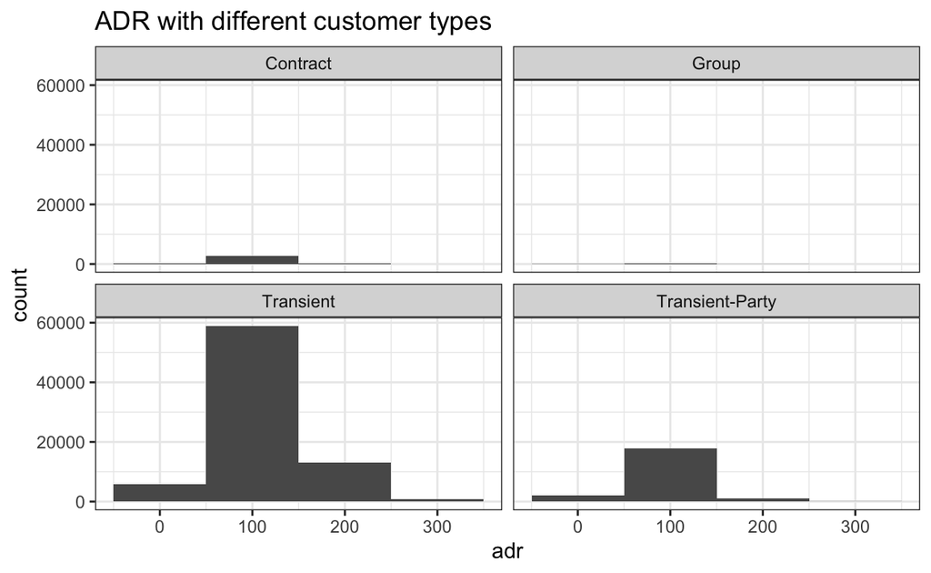

```r
all_data <- filter(HW3_data, adr > 0 & lead_time>0 & lead_time<300 & adr <300 )
ggplot(all_data, aes(adr)) +
  geom_histogram(binwidth = 100) +
  labs(title = "ADR with different customer types") +
  theme_bw() +
  facet_wrap(vars(customer_type))
```

### Conclusion

- What is missing from your final project? I need to do some background research into why the city hotel has less flexibility on the price than resort hotel to back up my conclusion found in the data and do a bit more analysis with the statement from my research.
- What do you hope to accomplish between now and submission time? I hope to add more evidence that I collected from my online research into my project to make it more persuasive.

### Bibliography

[1] https://en.wikipedia.org/wiki/Average_daily_rate